# TP6

## Exercice 1

```r
p <- 0.3
n <- 500
x <- rbinom(n,1,p)
```

```r
moy.taille <- cumsum(x)/(1:n)
```

```r
alpha <- 0.05
Binf.taille <- moy.taille-sqrt(moy.taille*(1-moy.taille)/(1:n))*qnorm(1-alpha/2)
Bsup.taille <- moy.taille+sqrt(moy.taille*(1-moy.taille)/(1:n))*qnorm(1-alpha/2)
```

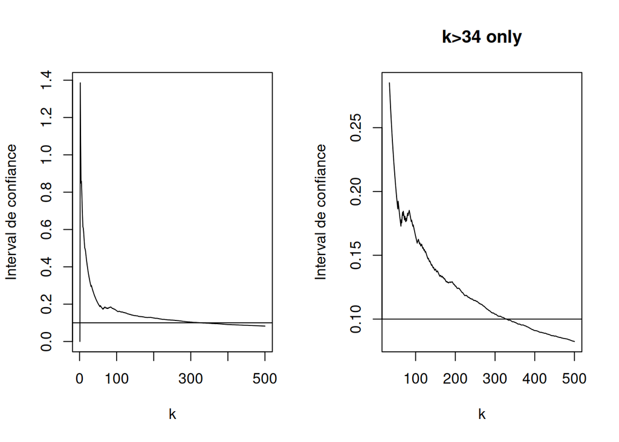

```r
amplitude.taille <- Bsup.taille-Binf.taille
par(mfrow=c(1,2))
plot(1:n,amplitude.taille,xlab="k",ylab="Interval de confiance",type="l"); abline(h=0.1)
plot((34:n),amplitude.taille[34:n],xlab="k",ylab="Interval de confiance", type="l",main="k>34 only"); abline(h=0.1)
```

```r
which.min(abs(amplitude.taille-0.1))
```

```
## [1] 329
```

Attention, pour que T.C.L. soit valide, il faut n suffisamment grand: np>10 et n(1-p)>10, soit ici n>34.

On lit la taille minimum cherchée: on doit prendre plus de environ 300 valeurs pour garantir une amplitude de 0.1.

```r
prop.test(sum(x),length(x)) # par défault, teste si p=0.5 (cf. TPs suivants) et, ce qui nous intéresse ici, donne l'interval de confiance à 95%
```

```
##
##  1-sample proportions test with continuity correction
##
## data:  sum(x) out of length(x), null probability 0.5
## X-squared = 57.122, df = 1, p-value = 4.096e-14
## alternative hypothesis: true p is not equal to 0.5
## 95 percent confidence interval:
##  0.2892569 0.3733980
## sample estimates:
##    p
## 0.33
```

```r
c(Binf.taille[n],Bsup.taille[n]) # on retrouve à peu près ce que l'on a calculé manuellement
```

```
## [1] 0.2887848 0.3712152
```

La légère différence entre notre calcul et l’intervalle de confiance de prop.test vient de notre approximation que $\bar{X}_n$ suit une la loi Normale (condition: np>10 et p(1-p)>10) alors que prop.test n’utilise pas cette approximation et n’a donc pas cette condition pour s’appliquer.

```r
prop.test(sum(x),length(x),conf.level=0.90) # on change le niveau de confiance avec l'option conf.level
```

```
##
##  1-sample proportions test with continuity correction
##
## data:  sum(x) out of length(x), null probability 0.5
## X-squared = 57.122, df = 1, p-value = 4.096e-14
## alternative hypothesis: true p is not equal to 0.5
## 90 percent confidence interval:
##  0.2954390 0.3664437
## sample estimates:
##    p
## 0.33
```

```r
alpha <- seq(0.01,0.30,0.01)
Binf.niveau <- mean(x)-sqrt(mean(x)*(1-mean(x))/n)*qnorm(1-alpha/2)
Bsup.niveau <- mean(x)+sqrt(mean(x)*(1-mean(x))/n)*qnorm(1-alpha/2)
amplitude.niveau <- Bsup.niveau-Binf.niveau
```

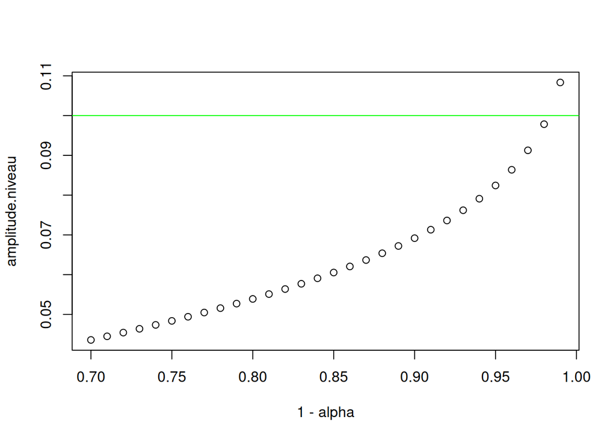

```r
plot(1-alpha,amplitude.niveau); abline(h=0.1,col="green")
```

Un niveau de confiance de 98% garanti une amplitude inférieure = 0.1.

8. On donne l’amplitude ampl = $2\sqrt{\frac{\bar{X}_n(1-\bar{X}_n)}{n}} u_{1-\frac{\alpha}{2}}$, et on cherche $1-\alpha$:

```r
ampl <- 0.1
u <- ampl/(2*sqrt(mean(x)*(1-mean(x))/n))
alphaopt <- (1-pnorm(u))*2
1-alphaopt
```

```
## [1] 0.9825799
```

```r
# abline(v=alphaopt,col=2)
```

# Exercice 2

```r
data <- read.csv("~/Personal/University/Semestre_4/401_STA/TP/Donnees/apnee.csv")
poidsH <- data[data$sex==0,"poids"]
```

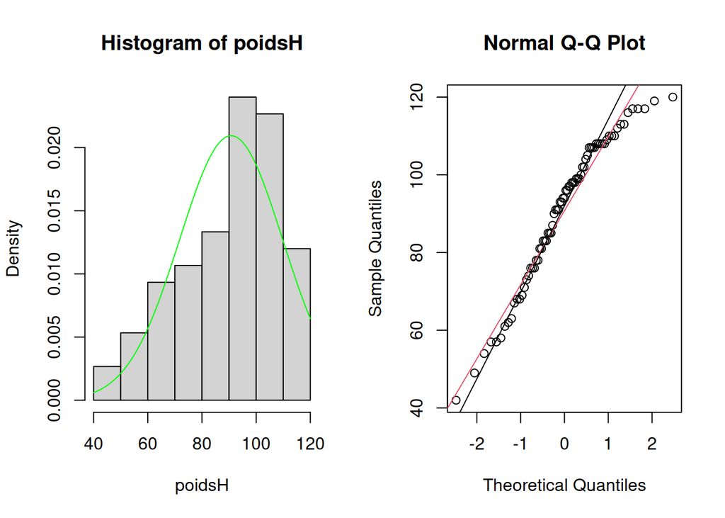

```r
par(mfrow=c(1,2))
hist(poidsH,prob=TRUE)
curve(dnorm(x,mean=mean(poidsH),sd = sd(poidsH)),col="green",add=T)
qqnorm(poidsH)#le quantile-quantile plot pour tester la loi normale
abline(mean(poidsH),sd(poidsH),col=2)#la droite de Henry
qqline(poidsH)
```

La répartition est très proche de la gaussienne, mais n’est pas parfaite et dévie un peu vers la droite. Notons que n étant grand, d’après le théorème central limite (TCL), la moyenne et la variance empirique suivent de toute façon une distribution gaussienne, même si la loi des données n’est pas gaussienne.

```r
cat("mu =",mean(poidsH), "sig =",sd(poidsH))
```

```
## mu = 90.77333 sig = 19.05013
```

```r
sigma <- 19
n<-length(poidsH)
u<-qnorm(1-0.05/2)
Binf<-mean(poidsH)-u*sigma/sqrt(n)
Bsup<-mean(poidsH)+u*sigma/sqrt(n)
cat("Bornes avec sigma connnu: [",Binf,";",Bsup,"]\n")
```

```
## Bornes avec sigma connnu: [ 86.47331 ; 95.07336 ]
```

```r
t<-qt(1-0.05/2,n-1)
Binf<-mean(poidsH)-t*sd(poidsH)/sqrt(n)
Bsup<-mean(poidsH)+t*sd(poidsH)/sqrt(n)
cat("Bornes avec sigma inconnu : [",Binf,";",Bsup,"]\n")
```

```
## Bornes avec sigma inconnu : [ 86.3903 ; 95.15637 ]
```

```r
t.test(poidsH)
```

```
##
##  One Sample t-test
##
## data:  poidsH
## t = 41.266, df = 74, p-value < 2.2e-16
## alternative hypothesis: true mean is not equal to 0
## 95 percent confidence interval:
##  86.39030 95.15637
## sample estimates:
## mean of x
##  90.77333
```

t.test donne bien l’intervalle de confiance avec sigma inconnu que l’on a trouvé précédement.

```r
t.test(poidsH,conf.level=0.99)
```

```
##
##  One Sample t-test
##
## data:  poidsH
## t = 41.266, df = 74, p-value < 2.2e-16
## alternative hypothesis: true mean is not equal to 0
## 99 percent confidence interval:
##  84.95747 96.58920
## sample estimates:
## mean of x
##  90.77333
```

```r
alpha <- 0.1
S2 <- var(poidsH)*(n-1)/n
Binf <- n*S2/qchisq(1-alpha/2,n-1)
Bsup <- n*S2/qchisq(alpha/2,n-1)
cat("Bornes pour alpha = 0.1: [",Binf,";",Bsup,"]\n")
```

```
## Bornes pour alpha = 0.1: [ 282.4435 ; 486.6012 ]
```

# Exercice 3

```r
apnee.fumeurs <- data[data$tabac==1,"apnee"]
apnee.non.fumeurs <- data[data$tabac==0,"apnee"]
p1<-mean(apnee.fumeurs)
p2<-mean(apnee.non.fumeurs)
```

Calcul à la main avec l’approximation Gaussienne (après avoir vérifié que p1$\times$length(apnee.fumeurs)>10 et p2$\times$length(apnee.non.fumeurs)>10 avec p1 et p2<0.5):

```r
alpha <- 0.1
B1inf <- p1-sqrt(p1*(1-p1)/length(apnee.fumeurs))*qnorm(1-0.1/2)
B1sup <- p1+sqrt(p1*(1-p1)/length(apnee.fumeurs))*qnorm(1-0.1/2)
B2inf <- p2-sqrt(p2*(1-p2)/length(apnee.non.fumeurs))*qnorm(1-0.1/2)
B2sup <- p2+sqrt(p2*(1-p2)/length(apnee.non.fumeurs))*qnorm(1-0.1/2)
cat("Bornes fumeurs: [",B1inf," ; ",B1sup,"]\n")
```

```
## Bornes fumeurs: [ 0.2171987  ;  0.4078013 ]
```

```r
cat("Bornes non fumeurs: [",B2inf," ; ",B2sup,"]\n")
```

```
## Bornes non fumeurs: [ 0.2815127  ;  0.5518206 ]
```

Lecture des intervalles de confiance avec prop.test:

```r
prop.test(sum(apnee.fumeurs),length(apnee.fumeurs),conf.level = 0.9)
```

```
##
##  1-sample proportions test with continuity correction
##
## data:  sum(apnee.fumeurs) out of length(apnee.fumeurs), null probability 0.5
## X-squared = 8.2656, df = 1, p-value = 0.00404
## alternative hypothesis: true p is not equal to 0.5
## 90 percent confidence interval:
##  0.2195748 0.4218524
## sample estimates:
##      p
## 0.3125
```

```r
prop.test(sum(apnee.non.fumeurs),length(apnee.non.fumeurs),conf.level = 0.9)
```

```
##
##  1-sample proportions test with continuity correction
##
## data:  sum(apnee.non.fumeurs) out of length(apnee.non.fumeurs), null probability 0.5
## X-squared = 0.69444, df = 1, p-value = 0.4047
## alternative hypothesis: true p is not equal to 0.5
## 90 percent confidence interval:
##  0.2797252 0.5664122
## sample estimates:
##         p
## 0.4166667
```

Les intervalles ont une grande partie commune, ce qui laisse penser que p1=p2 est possible.